# Assignement Week 08

Laurin Schaller

2023-04-28

# Downloading data and setup

```r
download.file("https://ethz-ins.org/content/mouse_mm38_hippocampus.peakCounts.SE.rds", "mouse_mm38_hippocampus.peakCounts.SE.rds")
```

```r
suppressPackageStartupMessages({
  library(epiwraps)
  library(motifmatchr)
  library(MotifDb)
  library(universalmotif)
  library(sechm)
  library(BiocParallel)
  library(ggplot2)
  library(chromVAR) # for motif accessibility estimation
  library(SummarizedExperiment) # data structure
  library(limma) # for statistical analysis
})
```

```
## See system.file("LICENSE", package="MotifDb") for use restrictions.
```

```r
# to control multithreading, unix users can use:
#register(MulticoreParam(4))
# for windows users, rather one of the following:
register(SerialParam())
# register(SnowParam(2))
```

# Reading data and data exploration

We can see that there are three data sets for each gender and both control and experiment conditions. These are the amount of aligned fragments per peak. Just like in the practical we can also denote this data with conditions.

```r
filename <- "mouse_mm38_hippocampus.peakCounts.SE.rds"
seData <- readRDS(filename)
seData
```

```
## class: RangedSummarizedExperiment
## dim: 20660 12
## metadata(0):
## assays(1): counts
## rownames: NULL
## rowData names(0):
## colnames(12): Control_female_GSM6041841.bam
##   Control_female_GSM6041842.bam ... FSS_male_GSM6041857.bam
##   FSS_male_GSM6041858.bam
## colData names(1): depth
```

```r
colnames(seData)
```

```
##  [1] "Control_female_GSM6041841.bam" "Control_female_GSM6041842.bam"
##  [3] "Control_female_GSM6041843.bam" "Control_male_GSM6041844.bam"
##  [5] "Control_male_GSM6041845.bam"   "Control_male_GSM6041846.bam"
##  [7] "FSS_female_GSM6041853.bam"     "FSS_female_GSM6041854.bam"
##  [9] "FSS_female_GSM6041855.bam"     "FSS_male_GSM6041856.bam"
## [11] "FSS_male_GSM6041857.bam"       "FSS_male_GSM6041858.bam"
```

```r
seData$condition <- c("CTRL","CTRL","CTRL", "CTRL","CTRL","CTRL", "FSS", "FSS", "FSS", "FSS", "FSS", "FSS")
seData$condition
```

```
##  [1] "CTRL" "CTRL" "CTRL" "CTRL" "CTRL" "CTRL" "FSS"  "FSS"  "FSS"  "FSS"
## [11] "FSS"  "FSS"
```

```r
colData(seData)
```

```
## DataFrame with 12 rows and 2 columns
##                                   depth   condition
##                               <numeric> <character>
## Control_female_GSM6041841.bam  73170149        CTRL
## Control_female_GSM6041842.bam  93995034        CTRL
## Control_female_GSM6041843.bam  40167775        CTRL
## Control_male_GSM6041844.bam    70491005        CTRL
## Control_male_GSM6041845.bam    84985977        CTRL
## ...                                 ...         ...
## FSS_female_GSM6041854.bam      73674456         FSS
## FSS_female_GSM6041855.bam      49285912         FSS
## FSS_male_GSM6041856.bam        82385764         FSS
## FSS_male_GSM6041857.bam        68623011         FSS
## FSS_male_GSM6041858.bam        81801232         FSS
```

# Get the database of motifs

Last assignment I had used a lot of motif data from Jaspar so lets see what would happen if we used **JASPAR_CORE** instead. It creates a MotifList of only 47 entries. This is less than the hocomoco database. So it is not as extensive.

```r
motifs <- query(MotifDb, c("JASPAR_CORE", "mus"))
length(motifs)
```

```
## [1] 47
```

```r
motifs <- query(MotifDb, c("HOCOMOCOv11-core", "Hsapiens"))
length(motifs)
```

```
## [1] 400
```

```r
motifs <- do.call(TFBSTools::PWMatrixList, setNames(
           universalmotif::convert_motifs(motifs, class="TFBSTools-PWMatrix"),
           mcols(motifs)$geneSymbol))
```

#Reference genome Loading the mouse GRCm38 reference genome from the week 06 practical. This created a DNASringSet which is quite large at 3GB. Not sure if there is a more resourceful way of loading it.

```r
library(AnnotationHub)
library(Biostrings)
ah <- AnnotationHub(localHub=TRUE)
```

```
## Using 'localHub=TRUE'
##   If offline, please also see BiocManager vignette section on offline use
```

```
## snapshotDate(): 2023-04-06
```

```r
genome <- ah[["AH68356"]]
```

```
## loading from cache
```

```
## require("rtracklayer")
```

```r
genomeSeq <- Biostrings::getSeq(genome)
tail(genomeSeq)
```

```
## DNAStringSet object of length 6:
##     width seq                                               names
## [1] 23158 CATAAAACATTTTGTGCAATCTC...ATCAAAAGATGGCCTAGTCGGCC GL456382.1
## [2] 22974 CTGCTGCTTGCTATGGCTGGTAA...AGCAACCCTGACCTGCTCCCGTG GL456359.1
## [3] 21240 TCCTTGGGGGGCATACGCCCAGA...GAAAATGAGACACAAACACTGTA GL456396.1
## [4] 20208 GAAGGAAGGAAGGAAGGAAGGAA...ACTCTGTTGCAGGCTGCCTTCCA GL456368.1
## [5] 14945 GTGTGTGTGTGTGTGTGTGTGTG...GCCCGAGAGGTTTCTGCCTCAGG JH584292.1
## [6]  1976 GGCTGAGCGGTGACATCATGGGC...ACCGCACTGGGCAGAAGCCCGTG JH584295.1
```

# Adding GC bias, find motifs within peaks, calculating deviations

We can see that the motifmatchr gives us an object with our 20660 peaks and the 400 motifs we have retrieved from the motifDB. The deviations data has a dimension of 400x12 which corresponds to our 6 controls and 6 expierment conditions.

```r
seData <- chromVAR::addGCBias(seData, genome=genomeSeq)
moi <- motifmatchr::matchMotifs(motifs, subject=seData, genome=genomeSeq)
moi
```

```
## class: RangedSummarizedExperiment
## dim: 20660 400
## metadata(0):
## assays(1): motifMatches
## rownames: NULL
## rowData names(1): bias
## colnames(400): AHR AIRE ... ZNF8 ZSC22
## colData names(1): name
```

```r
dev <- chromVAR::computeDeviations(object = seData, annotations=moi,
                                   background_peaks=getBackgroundPeaks(seData, niterations=1000))
dev
```

```
## class: chromVARDeviations
## dim: 400 12
## metadata(0):
## assays(2): deviations z
## rownames(400): AHR AIRE ... ZNF8 ZSC22
## rowData names(3): name fractionMatches fractionBackgroundOverlap
## colnames(12): Control_female_GSM6041841.bam
##   Control_female_GSM6041842.bam ... FSS_male_GSM6041857.bam
##   FSS_male_GSM6041858.bam
## colData names(2): depth condition
```

```r
colData(dev)
```

```
## DataFrame with 12 rows and 2 columns
##                                   depth   condition
##                               <numeric> <character>
## Control_female_GSM6041841.bam  73170149        CTRL
## Control_female_GSM6041842.bam  93995034        CTRL
## Control_female_GSM6041843.bam  40167775        CTRL
## Control_male_GSM6041844.bam    70491005        CTRL
## Control_male_GSM6041845.bam    84985977        CTRL
## ...                                 ...         ...
## FSS_female_GSM6041854.bam      73674456         FSS
## FSS_female_GSM6041855.bam      49285912         FSS
## FSS_male_GSM6041856.bam        82385764         FSS
## FSS_male_GSM6041857.bam        68623011         FSS
## FSS_male_GSM6041858.bam        81801232         FSS
```

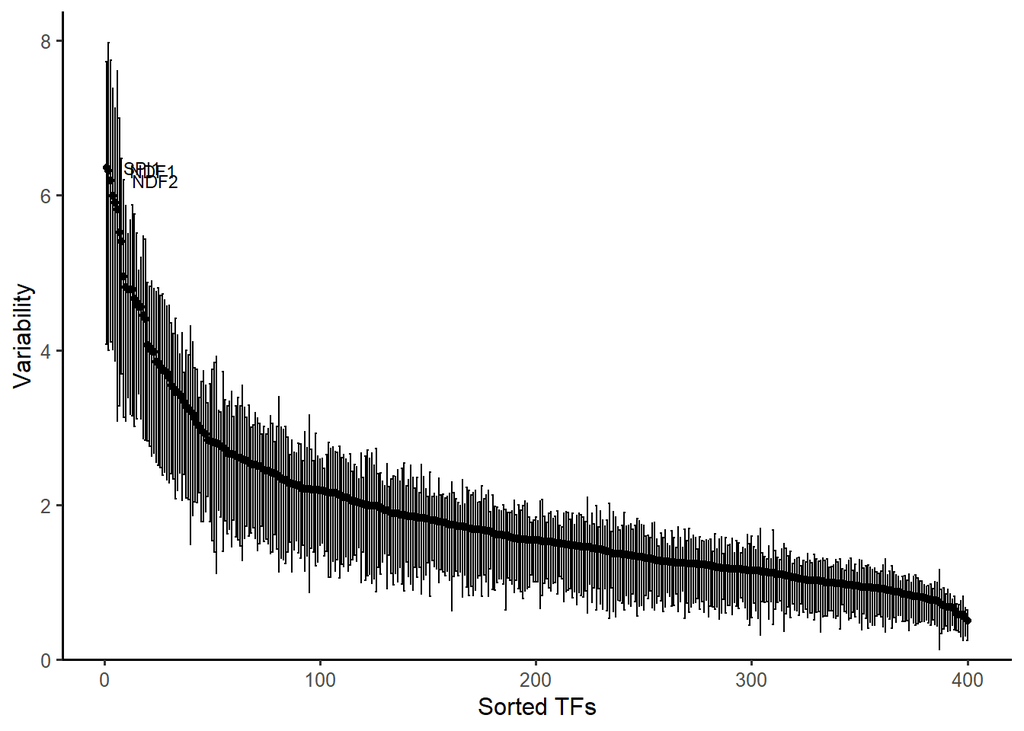

```r
variability <- computeVariability(dev)
plotVariability(variability)
```

# Normalization and deviation data

```r
head(assays(dev)$z)
```

```
##      Control_female_GSM6041841.bam Control_female_GSM6041842.bam
## AHR                  -0.5012047964                     0.1524239
## AIRE                  0.0009434292                    -0.4171673
## ALX1                  0.6662599177                     0.2261389
## ANDR                  1.3826962870                    -2.1102617
## AP2A                  2.4448505544                    -0.4771479
## AP2B                  2.1098023323                    -0.5261952
##      Control_female_GSM6041843.bam Control_male_GSM6041844.bam
## AHR                      0.4265205                  -0.2432774
## AIRE                    -2.3750784                   1.9920101
## ALX1                    -0.2036665                  -0.3850045
## ANDR                    -0.8506074                   2.1999901
## AP2A                    -1.9543982                   3.0521572
## AP2B                    -1.1365200                   1.7924227
##      Control_male_GSM6041845.bam Control_male_GSM6041846.bam
## AHR                   0.64034363                  -0.7241426
## AIRE                 -0.06508098                  -0.2407150
## ALX1                  0.45522778                  -1.3199005
## ANDR                 -1.29246548                   0.4579895
## AP2A                  0.97145282                   2.5087231
## AP2B                 -1.05599137                   0.6258964
##      FSS_female_GSM6041853.bam FSS_female_GSM6041854.bam
## AHR                  0.8152538                -0.3094421
## AIRE                 0.9171294                 1.4190768
## ALX1                -0.7274735                 0.8206955
## ANDR                 2.5744576                -1.0341139
## AP2A                 1.6114249                -2.9772566
## AP2B                 0.8406881                -0.3144047
##      FSS_female_GSM6041855.bam FSS_male_GSM6041856.bam FSS_male_GSM6041857.bam
## AHR                -1.32970063              -1.0168198               0.5808797
## AIRE                0.75500757               1.6578498               1.5501303
## ALX1                0.09378384               0.7313844              -0.3806283
## ANDR                2.24395241               0.2576191               3.1868729
## AP2A                1.94774490               1.6998007               0.9539566
## AP2B                0.25951432               1.5797650               0.8696099
##      FSS_male_GSM6041858.bam
## AHR               0.02926519
## AIRE              0.24550980
## ALX1             -0.28904416
## ANDR             -1.51037492
## AP2A              0.07932146
## AP2B             -0.54739713
```

```r
assays(dev)$norm <- scale(assays(dev)$z)
dev
```

```
## class: chromVARDeviations
## dim: 400 12
## metadata(0):
## assays(3): deviations z norm
## rownames(400): AHR AIRE ... ZNF8 ZSC22
## rowData names(3): name fractionMatches fractionBackgroundOverlap
## colnames(12): Control_female_GSM6041841.bam
##   Control_female_GSM6041842.bam ... FSS_male_GSM6041857.bam
##   FSS_male_GSM6041858.bam
## colData names(2): depth condition
```

```r
dev$condition
```

```
##  [1] "CTRL" "CTRL" "CTRL" "CTRL" "CTRL" "CTRL" "FSS"  "FSS"  "FSS"  "FSS"
## [11] "FSS"  "FSS"
```

```r
head(deviations(dev))
```

```
##      Control_female_GSM6041841.bam Control_female_GSM6041842.bam
## AHR                  -1.919088e-02                   0.005976075
## AIRE                  1.755484e-05                  -0.008671059
## ALX1                  1.280327e-02                   0.005910411
## ANDR                  1.359631e-02                  -0.025581908
## AP2A                  2.639341e-02                  -0.005573117
## AP2B                  1.993079e-02                  -0.005430053
##      Control_female_GSM6041843.bam Control_male_GSM6041844.bam
## AHR                     0.10653268                 -0.01025355
## AIRE                   -0.30955908                  0.04814623
## ALX1                   -0.02839439                 -0.01056637
## ANDR                   -0.05526304                  0.02790690
## AP2A                   -0.14336417                  0.04278636
## AP2B                   -0.07650221                  0.02210655
##      Control_male_GSM6041845.bam Control_male_GSM6041846.bam
## AHR                  0.032399919                -0.030730997
## AIRE                -0.001477654                -0.004943569
## ALX1                 0.010880260                -0.029507025
## ANDR                -0.015810337                 0.004943308
## AP2A                 0.013746698                 0.030045182
## AP2B                -0.015341247                 0.006752024
##      FSS_female_GSM6041853.bam FSS_female_GSM6041854.bam
## AHR                0.035880948              -0.026569148
## AIRE               0.020111274               0.062757127
## ALX1              -0.017648158               0.043358454
## ANDR               0.029805403              -0.025578490
## AP2A               0.019663058              -0.075046879
## AP2B               0.009048394              -0.006985722
##      FSS_female_GSM6041855.bam FSS_male_GSM6041856.bam FSS_male_GSM6041857.bam
## AHR               -0.057736327            -0.031845207             0.028823196
## AIRE               0.013770855             0.031203124             0.033056321
## ALX1               0.002019269             0.015292235            -0.009156543
## ANDR               0.021271440             0.002491049             0.037680844
## AP2A               0.020802157             0.016513622             0.011105075
## AP2B               0.002617825             0.014002443             0.010553184
##      FSS_male_GSM6041858.bam
## AHR             0.0009269951
## AIRE            0.0044592801
## ALX1           -0.0058090345
## ANDR           -0.0139083330
## AP2A            0.0008484832
## AP2B           -0.0052732087
```

# Different conditions based on control vs. healthy + female vs. male

```r
#dev$condition <- c("CTRL","CTRL","CTRL", "CTRL","CTRL","CTRL", "FSS", "FSS", "FSS", "FSS", "FSS", "FSS")
dev$condition <- factor(dev$condition)
dev$condition <- relevel(dev$condition, c("CTRL"))
dev$condition
```

```
##  [1] CTRL CTRL CTRL CTRL CTRL CTRL FSS  FSS  FSS  FSS  FSS  FSS
## Levels: CTRL FSS
```

```r
mm <- model.matrix(~dev$condition)
mm
```

```
##    (Intercept) dev$conditionFSS
## 1            1                0
## 2            1                0
## 3            1                0
## 4            1                0
## 5            1                0
## 6            1                0
## 7            1                1
## 8            1                1
## 9            1                1
## 10           1                1
## 11           1                1
## 12           1                1
## attr(,"assign")
## [1] 0 1
## attr(,"contrasts")
## attr(,"contrasts")$`dev$condition`
## [1] "contr.treatment"
```

# Fit exploration and volcano plot

EDIT: I only later realized these are not the adjusted p-values, but could not acces them through **res2[res2$adj.P.Val < 0.05]**

These are GCR and PRGR which we already know to be involved in the stress response.

```r
fit <- eBayes(lmFit(assays(dev)$norm, mm))
order(fit$F.p.value)
```

```
##   [1] 106 251 172  27 170 160 173 313 306 270 187 178 180 370 253   2  95 217
##  [19]  16 188  94 179  87 222 314  93 395  90  35 324 171 234  65  34 274 280
##  [37] 196 312 279 377 210 215 264  10 237 240  97  96  86 223 352  98 208 169
##  [55]  49 294 159 147 360 142 227 126 246  85 369  42 376 139 198 386  23 242
##  [73] 236  84 122 332 394 328 315 303 182 155 213  41 228 252 209 103  19   5
##  [91] 397 378 351  20 216  69  68 311 275 302 263 135 184  11 389 232 320 277
## [109]  43 206 143 136 304 273  45 298 286 257 299 354  62 132 372 197 105  88
## [127] 323 108 181  39 318  26 107 175  91 337 120 363 127  92 391  51 373 109
## [145] 393 398 235 346 212 247 356   7 134 271 349  63 152 225 199 183 357   4
## [163] 327 284 256 104  66 131  22 238  99 111 158 166  67  38 250 272 291  31
## [181] 301 380 300 224   8 148  17 310   9 115  44  74 255 156  75 114  37 113
## [199]  14  52 140 368 230  21 305 249 128 157  54 309 193 117 174  32  73  71
## [217] 219 400 226  77  79 129 387 163 220 137 192  60 177  64 211 307  82  55
## [235]  70 102   1 189 278 316 375  53 118 292  12 261 146 339  80 342  81 221
## [253]  57 345 138 382  89  56 141 338 254 239 191 333  33  83 243  28 343 268
## [271]   6 276 123 353 285 347 289 350 390 162 317 125 269 176  46  24 130 340
## [289] 385 336 145  59 293 295 110 218 283 207 100 121 144 341 358  36 359 233
## [307] 194  50 366  48 297 101 229 190 326 296 321 362 322 335  72  61 186 334
## [325] 149 195  58  25 168  78 201 282   3 267 133 330 260 371 355 388 167 319
## [343]  76  30 124 379 331 116 384 392 150 329 281 308 367 259 204  40 361 383
## [361] 185 287 399 245 365 241 202  29  13 153 244 396 119 161 164 266 112 348
## [379] 364 381 214 203 374  47 290 344 265  15 262 154 151  18 205 165 200 258
## [397] 288 231 325 248
```

```r
fit$F.p.value[106]
```

```
## [1] 0.000235014
```

```r
fit$F.p.value[251]
```

```
## [1] 0.0002839178
```

```r
fit$F.p.value[172]
```

```
## [1] 0.07281132
```

```r
res <- as.data.frame(topTable(fit, number = Inf))
```

```
## Removing intercept from test coefficients
```

```r
head(res)
```

```
##            logFC     AveExpr         t      P.Value  adj.P.Val         B
## GCR    4.4450979  0.22449106  5.617643 6.028532e-05 0.01562639  2.027484
## PRGR   3.6150813  0.27818947  5.473492 7.813194e-05 0.01562639  1.791271
## MEF2C -1.1673545 -0.13279111 -2.454787 2.758259e-02 0.99981843 -3.613682
## CDX1   0.8583810  0.03000770  2.190195 4.568909e-02 0.99981843 -4.061938
## MEF2A -0.9400848 -0.05665925 -2.142177 4.998899e-02 0.99981843 -4.140844
## MEF2D -1.1054762 -0.06235414 -2.102081 5.386414e-02 0.99981843 -4.206081
```

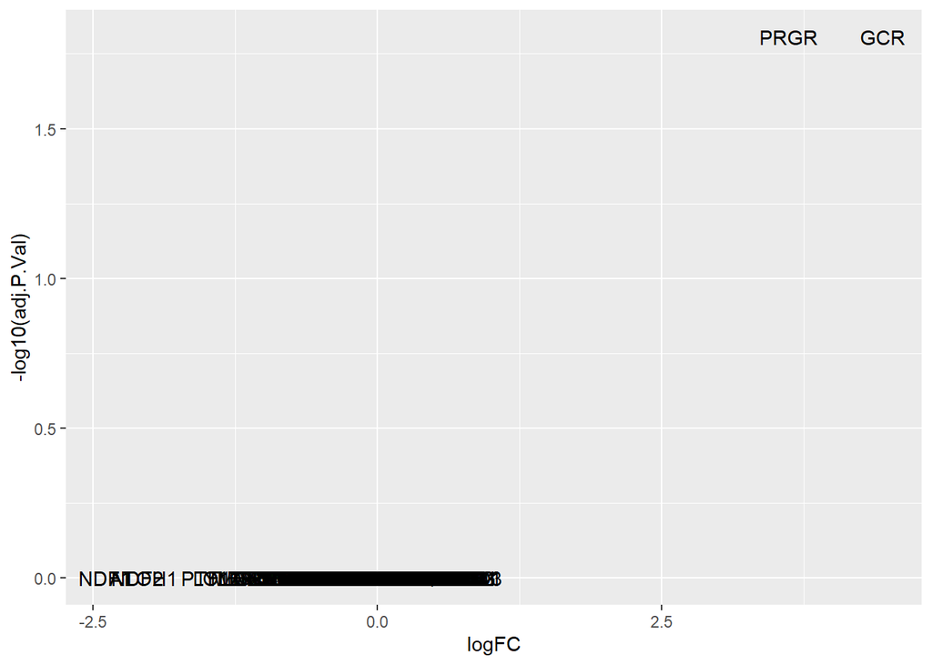

```r
res$TF <- row.names(res)
ggplot(res, aes(logFC, -log10(adj.P.Val), label=TF)) + geom_text()
```

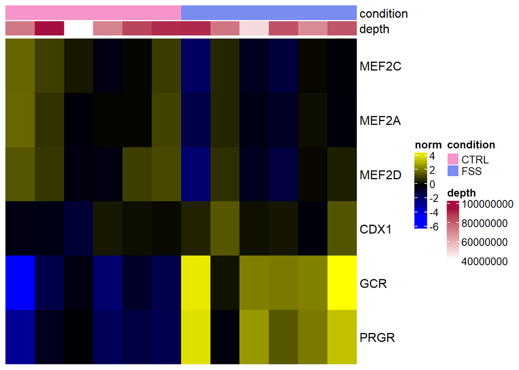

```r
sechm(dev, features = head(row.names(res)), assayName="norm", top_annotation = c("condition", "depth"))
```

# Adding gender information to graph

Just to play around with this data format

```r
dev$gender <- c("FEMALE","FEMALE","FEMALE", "MALE","MALE","MALE", "FEMALE", "FEMALE", "FEMALE", "MALE", "MALE", "MALE")
dev$gender <- factor(dev$gender)
dev$gender <- relevel(dev$gender, c("FEMALE"))
dev$gender
```

```
##  [1] FEMALE FEMALE FEMALE MALE   MALE   MALE   FEMALE FEMALE FEMALE MALE
## [11] MALE   MALE
## Levels: FEMALE MALE
```

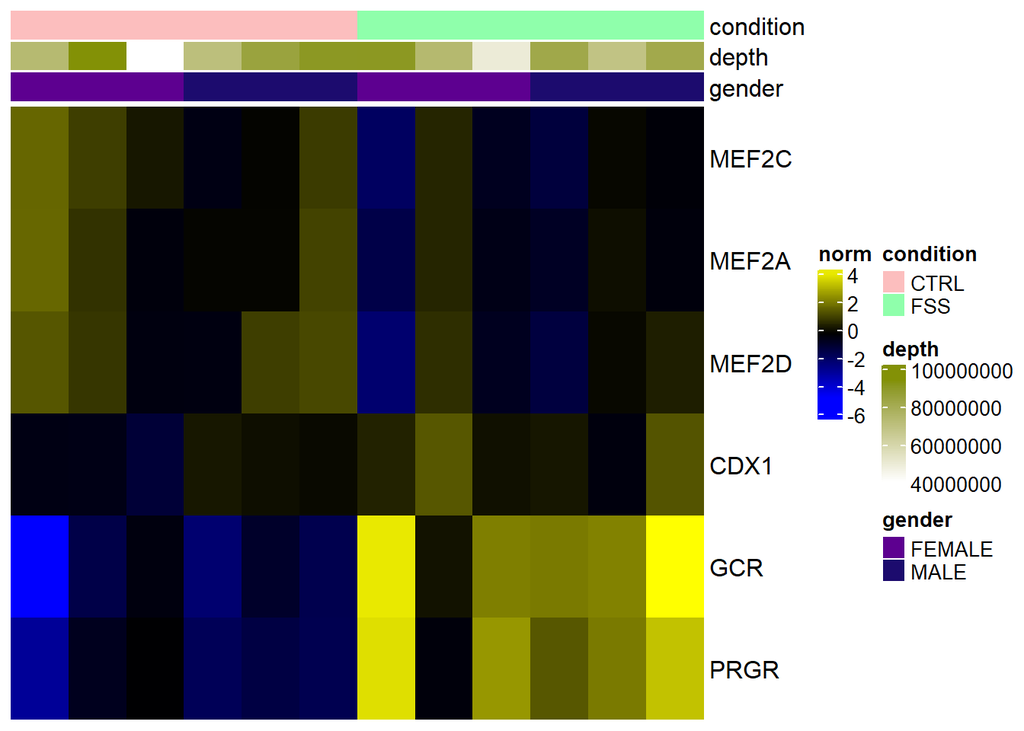

```r
sechm(dev, features = head(row.names(res)), assayName="norm", top_annotation = c("condition", "depth", "gender"))
```

# New model but for gender differences

We have to be careful now as there are 3 female controls, 3 male controls, 3 female experiment conditions and then 3 male experiment conditions. But this looks right.

```r
mm2 <- model.matrix(~dev$gender)
mm2
```

```
##    (Intercept) dev$genderMALE
## 1            1              0
## 2            1              0
## 3            1              0
## 4            1              1
## 5            1              1
## 6            1              1
## 7            1              0
## 8            1              0
## 9            1              0
## 10           1              1
## 11           1              1
## 12           1              1
## attr(,"assign")
## [1] 0 1
## attr(,"contrasts")
## attr(,"contrasts")$`dev$gender`
## [1] "contr.treatment"
```

```r
fit2 <- eBayes(lmFit(assays(dev)$norm, mm2))
order(fit2$F.p.value)
```

```
##   [1] 345 329 374 335 325 334 400  55  50  47 307  54 392 151 322 327 319 154
##  [19] 292 293 138 371  56 259 337 393  13 265  21 196 289 267 262  53 362 140
##  [37] 290  59 163 175 197 333 310 210 218 330 266 132 382 224 141 321 300  60
##  [55] 149  43 176 346 291  64  75 338 379 135 167 324  57 136 331 242 299 303
##  [73] 361   7 257 253   8  58 364 100 398 128 212 126 130 311 301 377 368 204
##  [91]  11 211  85  25  61  88 198 261  10 137 320 328   5  70 260 153  42 208
## [109] 315 150  74 217 249  35 305 105  49 256  24 219 247 354 302  22 178 252
## [127]  12 347 298 264 395 162 258 121 263 359 365  65 179 385  44 183 235  40
## [145] 155  32 295  73 236 389 304 357 104 237  38 227  94 240 246  52 268  66
## [163] 103 280 355 117 225 230 245 274 122 277 356  26  93 152  45  39 358 271
## [181] 180 234 168  79 133 314  41 216  31  90  48 213  37 193 107 243 373 254
## [199] 372 184 287  84 139 222 370  36  98 238 332 203 157 199  95  76 123 110
## [217] 294 340 367 205 220 159 127 109 232 111 215 165 313 209   2 309  92 148
## [235] 272 233  87  51 116 160   3 281 166 323 351 226  78 191  82 336 120 255
## [253] 275  28 164 383 158 390 282  23 228 187 115 244  46  16  97 363 185 113
## [271] 349  71 188 182  99  81  19 221 134  86 143 192 125  20 169 312 391 229
## [289]  69  34 276 181 279   1  62 316 177 273 172 278  29 396 250  18 146  33
## [307] 387 118 308  80 174   9  91 375 284 223 348  83 343 360 156  14 241 306
## [325]  89  15  27 386 190 231 394 269 239 270 342 189  77 206 147 296 106   6
## [343] 317 248 201 145 142 194 114 161 207 186 397 171 286 102 101 350   4 144
## [361]  68 352 378  17  72 326 353 251 318  63  30 339 369 124 173  67 202 380
## [379] 288 285 170 376 131 366 195 384 283 341 388 119 381 214 297 112 108 344
## [397] 200  96 129 399
```

```r
fit2$F.p.value[345]
```

```
## [1] 1.188352e-07
```

```r
fit2$F.p.value[329]
```

```
## [1] 1.137838e-06
```

```r
fit2$F.p.value[335]
```

```
## [1] 2.527183e-05
```

```r
fit2$F.p.value[fit2$F.p.value < 0.05]
```

```
##  [1] 1.506969e-02 1.547163e-02 3.861213e-03 3.409436e-03 2.297956e-02
##  [6] 4.364272e-03 1.296709e-03 1.271737e-02 3.102879e-02 4.598507e-02
## [11] 9.958590e-03 2.997647e-02 5.829023e-03 7.130068e-03 3.165154e-02
## [16] 3.273052e-02 1.666804e-02 3.352245e-02 3.916110e-02 3.977232e-02
## [21] 4.949017e-02 1.279813e-02 2.145977e-02 1.535525e-02 4.158700e-02
## [26] 2.034121e-02 2.010462e-02 3.016824e-02 8.763196e-03 9.254668e-03
## [31] 4.181564e-03 3.871324e-02 6.583914e-03 6.032045e-03 4.060590e-05
## [36] 6.377378e-03 1.137838e-06 3.982130e-02 3.658376e-02 5.402274e-04
## [41] 2.527183e-05 1.431279e-02 1.188352e-07 2.809257e-02 1.127513e-02
## [46] 2.327063e-05 4.751760e-02 5.255465e-03 1.461631e-02 5.526300e-04
```

```r
res2 <- as.data.frame(topTable(fit2, number = Inf))
```

```
## Removing intercept from test coefficients
```

```r
head(res2)
```

```
##           logFC     AveExpr          t      P.Value    adj.P.Val        B
## ZFP42 -4.471172 -0.41219645 -10.663704 3.204652e-08 1.281861e-05 9.280613
## TYY1  -4.501360 -0.23108257  -9.009184 2.692395e-07 5.384791e-05 7.252639
## ZN384 -2.941276 -0.07123745  -6.991290 5.449283e-06 5.961862e-04 4.312524
## Z324A -2.213705 -0.06466151  -6.935857 5.961862e-06 5.961862e-04 4.223699
## THAP1 -2.189421  0.01171086  -6.653478 9.485529e-06 7.588423e-04 3.764237
## WT1   -1.900539 -0.12793228  -5.106757 1.465430e-04 9.075012e-03 1.042666
```

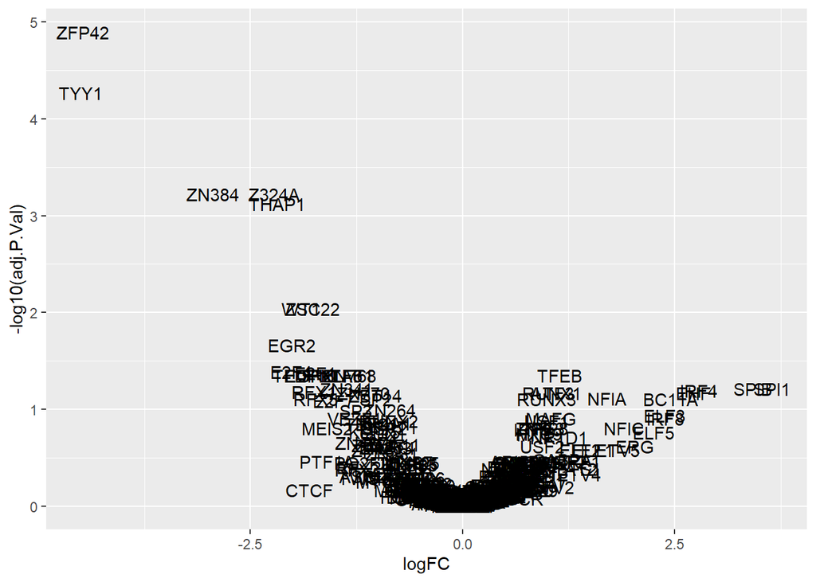

```r
res2$TF <- row.names(res2)
ggplot(res2, aes(logFC, -log10(adj.P.Val), label=TF)) + geom_text()
```

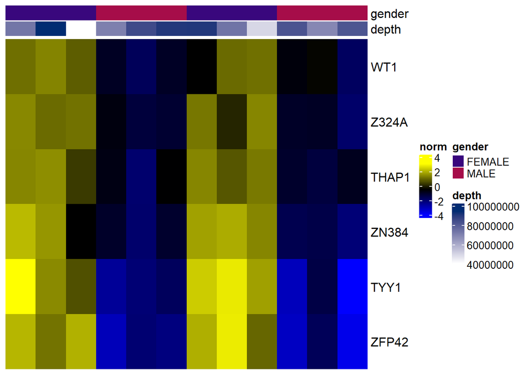

```r
sechm(dev, features = head(row.names(res2)), assayName="norm", top_annotation = c("gender", "depth"))
```